# IE 360 HW4-5

### ARIMA

```r
pr4_auto=auto.arima(pr4_ts_decompose_wm$random)
pr4_auto
```

```
## Series: pr4_ts_decompose_wm$random
## ARIMA(2,0,1) with non-zero mean
##
## Coefficients:
##          ar1      ar2      ma1    mean
##       1.0112  -0.5127  -0.7286  0.9606
## s.e.  0.0569   0.0431   0.0533  0.0085
##
## sigma^2 estimated as 0.09794:  log likelihood=-100.72
## AIC=211.45   AICc=211.6   BIC=231.38
```

```r
residuals(pr4_auto)
```

[output not shown]

[output cut: 70 more lines]

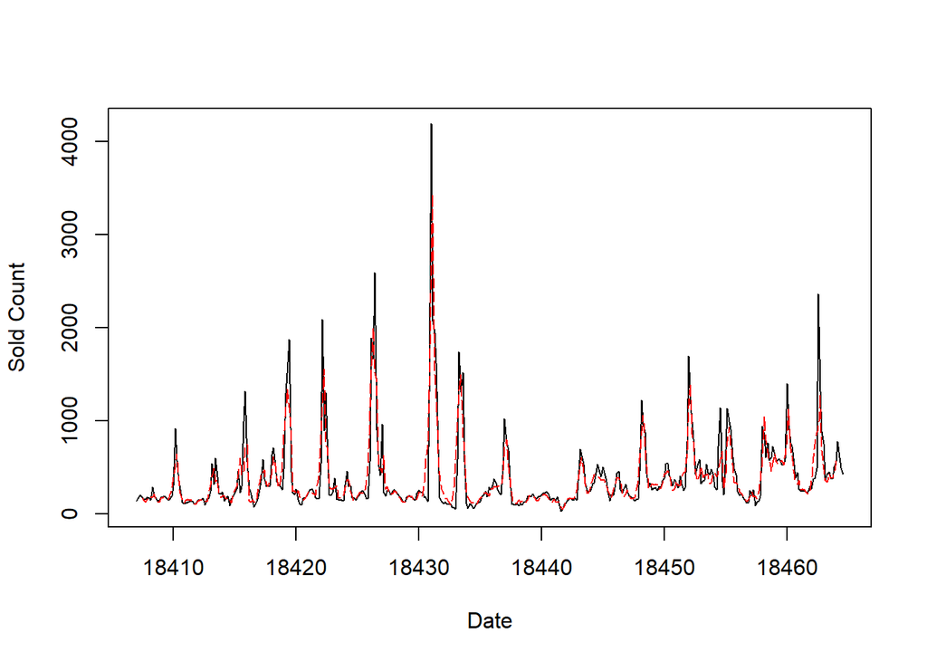

```r
pr4_fitted = pr4_ts_decompose_wm$random - residuals(pr4_auto)
pr4_fitted_transformed = pr4_fitted*pr4_ts_decompose_wm$seasonal*pr4_ts_decompose_wm$trend
plot(pr4_ts_w, xlab="Date", ylab="Sold Count")
points(pr4_fitted_transformed,type="l", col=2, lty=5)
```

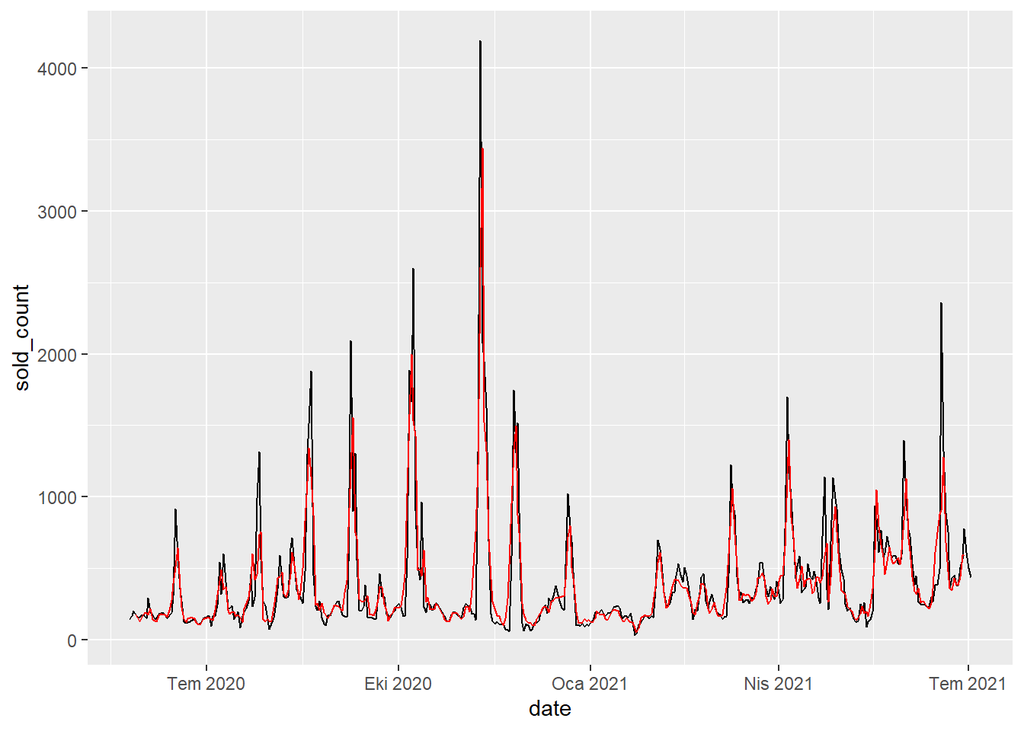

```r
pr4_predictions=cbind(sold_count=pr4_ts_w,fitted=pr4_fitted_transformed)
pr4_predictions=as.data.table(pr4_predictions)
pr4_predictions$date=product4$event_date
ggplot(pr4_predictions, aes(x=date, y=sold_count))+geom_line()+geom_line(aes(y=fitted),col="red")
```

## Product 5

### Data Adjustments

I added new data and sorted observations from old to new.

```r
product5= my_data[my_data$product_content_id==48740784,]
product5=(product5[order(product5$event_date),])
prd5_add=data[data$product_content_id==48740784,]
prd5_add=prd5_add[event_date>="2021-06-01",]
prd5_add
```

```
##      price event_date product_content_id sold_count visit_count favored_count
##  1: 599.98 2021-06-01           48740784          4         345            35
##  2: 599.98 2021-06-02           48740784          6         516            37
##  3: 599.98 2021-06-03           48740784          3         364            30
##  4: 599.98 2021-06-04           48740784          4         244            17
##  5:  -1.00 2021-06-05           48740784          0         225            17
##  6: 599.98 2021-06-06           48740784          3         224            10
##  7: 599.98 2021-06-07           48740784          2         228            21
##  8: 324.99 2021-06-08           48740784          2         173             9
##  9:  -1.00 2021-06-09           48740784          0         145            11
## 10: 349.99 2021-06-10           48740784          2         124            10
## 11:  -1.00 2021-06-11           48740784          0         127            10
## 12: 349.99 2021-06-12           48740784          2         145             7
## 13:  -1.00 2021-06-13           48740784          0         197            13
## 14: 699.98 2021-06-14           48740784          5         344            25
```

[output cut: 87 more lines]

```r
product5=rbind(product5,prd5_add)
product5=product5[event_date>"2020-09-28"]
```

### Visualizing

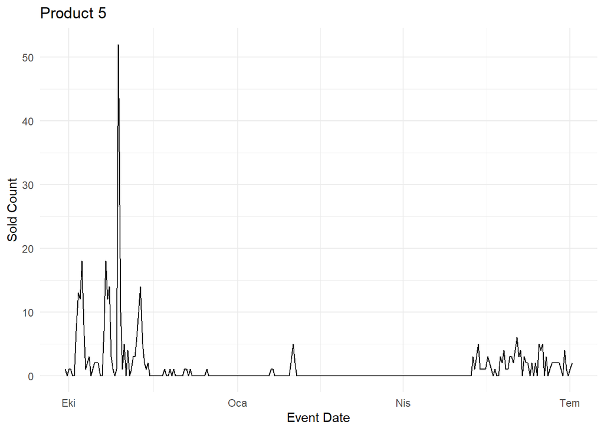

```r
(ggplot(product5,aes(x=event_date,y=sold_count))+
    geom_line()+
    theme_minimal()+
    labs(title="Product 5",y="Sold Count", x="Event Date"))
```

### Analyze Seasonality

In addition to visual analysis, I also used the acf function to test seasonality.

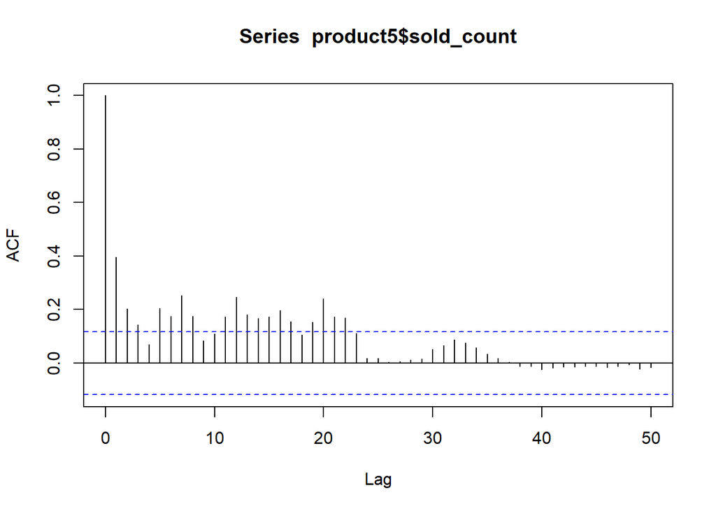

```r
acf(product5$sold_count,50)
```

### Decomposition

I made multiplicative and additive decomposition in weekly and monthly level.

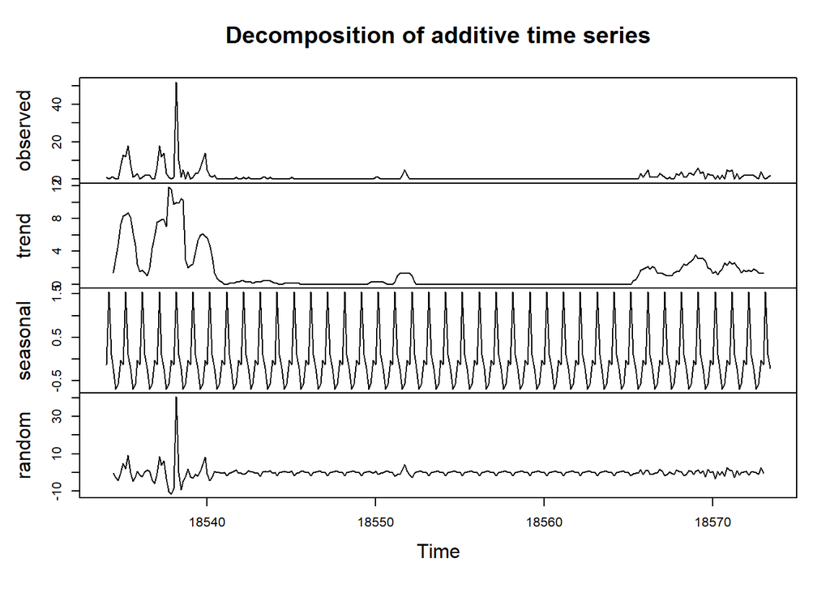

```r
pr5_ts_w=ts(product5$sold_count, frequency=7,start = min(product5$event_date))
pr5_ts_decompose_wa=decompose(pr5_ts_w)
pr5_ts_decompose_wm=decompose(pr5_ts_w, type="multiplicative")
plot(pr5_ts_decompose_wa)
```

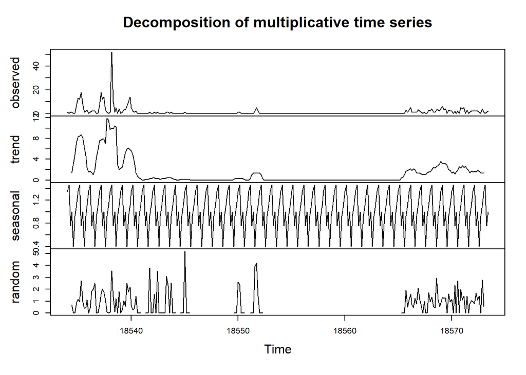

```r
plot(pr5_ts_decompose_wm)
```

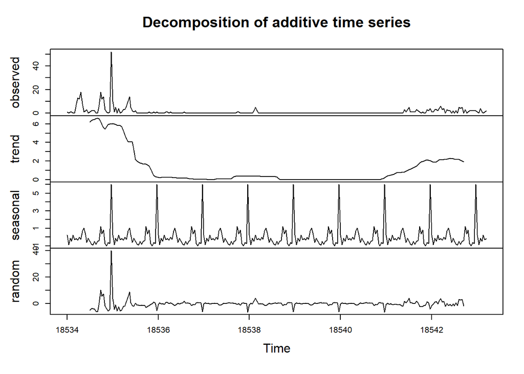

```r
pr5_ts_m=ts(product5$sold_count, frequency=30,start = min(product5$event_date))
pr5_ts_decompose_ma=decompose(pr5_ts_m)
pr5_ts_decompose_mm=decompose(pr5_ts_m, type="multiplicative")
plot(pr5_ts_decompose_ma)
```

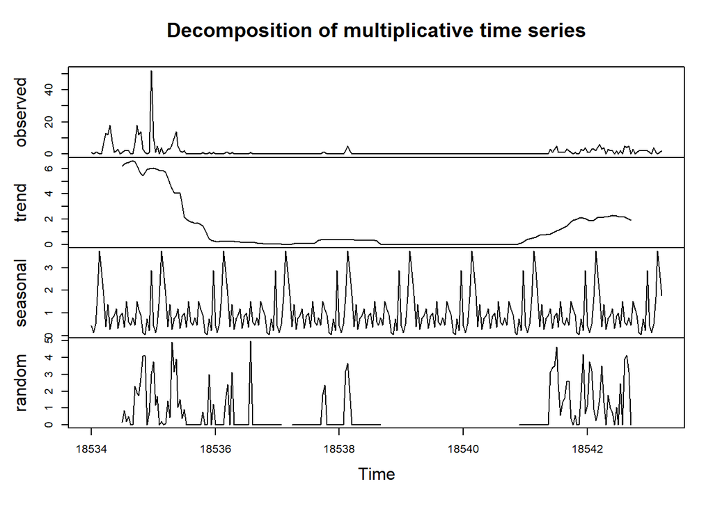

```r
plot(pr5_ts_decompose_mm)
```

## Product 6

### Data Adjustments

I added new data and sorted observations from old to new.

```r
product6= my_data[my_data$product_content_id==6676673,]
product6=(product6[order(product6$event_date),])
prd6_add=data[data$product_content_id==6676673,]
prd6_add=prd6_add[event_date>="2021-06-01",]
prd6_add
```

```
##      price event_date product_content_id sold_count visit_count favored_count
##  1: 115.56 2021-06-01            6676673        432       18160          1235
##  2: 115.90 2021-06-02            6676673        489       19821          1268
##  3: 112.05 2021-06-03            6676673        583       20136          1291
##  4: 110.84 2021-06-04            6676673        566       20963          1247
##  5: 116.63 2021-06-05            6676673        409       20495          1223
##  6: 116.83 2021-06-06            6676673        519       25199          1609
##  7: 119.97 2021-06-07            6676673        413       17791          1168
##  8: 117.60 2021-06-08            6676673        451       21730          1011
##  9: 115.10 2021-06-09            6676673        556       19680           989
## 10: 113.47 2021-06-10            6676673        515       19944           925
## 11: 115.87 2021-06-11            6676673        416       16298           865
## 12: 116.54 2021-06-12            6676673        392       15093           790
## 13: 116.86 2021-06-13            6676673        500       20584          1149
## 14: 117.87 2021-06-14            6676673        557       20221          1120
```

[output cut: 87 more lines]

```r
product6=rbind(product6,prd6_add)
```

### Visualizing

The plot of the series is shown below.There are several mean-shifts and the variance of the series is not constant.

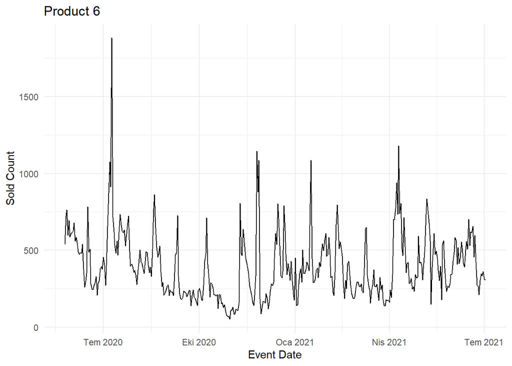

```r
(ggplot(product6,aes(x=event_date,y=sold_count))+
    geom_line()+
    theme_minimal()+
    labs(title="Product 6",y="Sold Count", x="Event Date"))
```

### Analyze Seasonality

In addition to visual analysis, I also used the acf function to test seasonality.

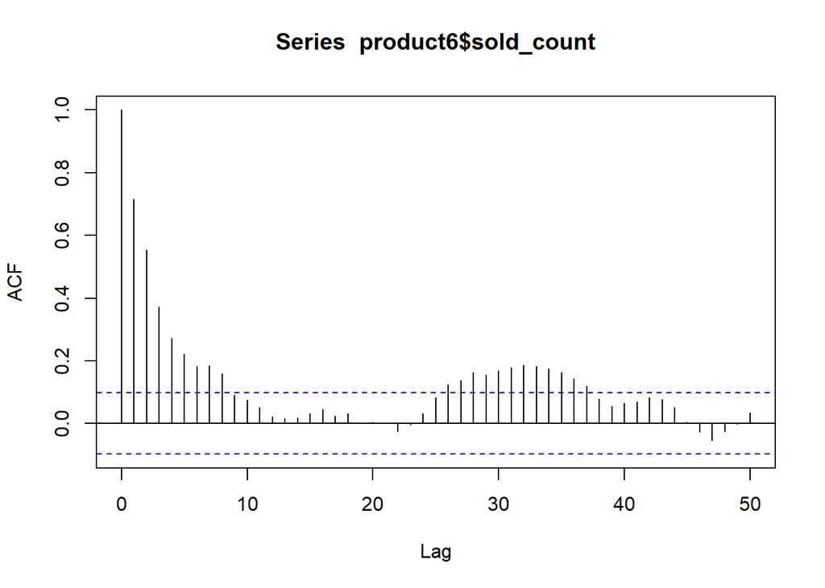

```r
acf(product6$sold_count,50)
```

### Decomposition

I made multiplicative and additive decomposition in weekly and monthly level.

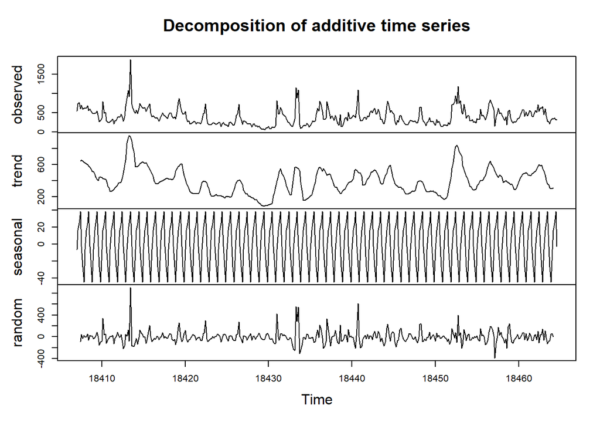

```r
pr6_ts_w=ts(product6$sold_count, frequency=7,start = min(product6$event_date))
pr6_ts_decompose_wa=decompose(pr6_ts_w)
pr6_ts_decompose_wm=decompose(pr6_ts_w, type="multiplicative")
plot(pr6_ts_decompose_wa)
```

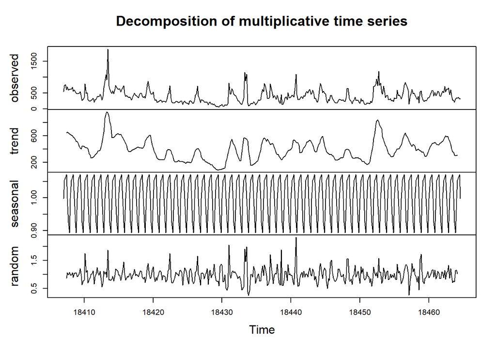

```r
plot(pr6_ts_decompose_wm)
```

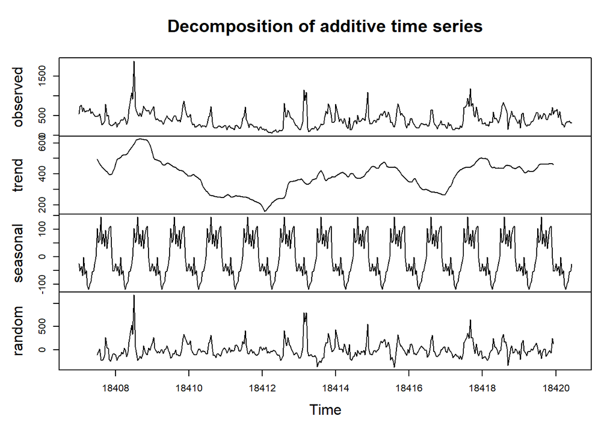

```r
pr6_ts_m=ts(product6$sold_count, frequency=30,start = min(product6$event_date))
pr6_ts_decompose_ma=decompose(pr6_ts_m)
pr6_ts_decompose_mm=decompose(pr6_ts_m, type="multiplicative")
plot(pr6_ts_decompose_ma)
```

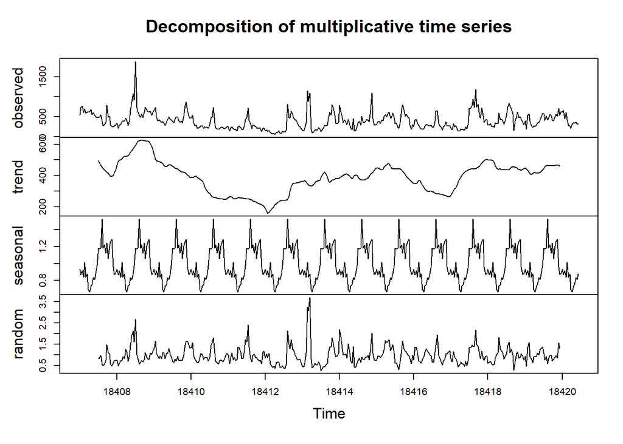

```r
plot(pr6_ts_decompose_mm)
```

### ARIMA

```r
pr6_auto=auto.arima(pr6_ts_decompose_wm$random)
pr6_auto
```

```
## Series: pr6_ts_decompose_wm$random
## ARIMA(3,0,2)(0,0,1)[7] with non-zero mean
##
## Coefficients:
##          ar1     ar2      ar3      ma1      ma2    sma1    mean
##       0.1428  0.3462  -0.4365  -0.0961  -0.6390  0.1154  0.9858
## s.e.  0.1258  0.1242   0.0545   0.1310   0.1293  0.0629  0.0035
##
## sigma^2 estimated as 0.04907:  log likelihood=38.11
## AIC=-60.22   AICc=-59.85   BIC=-28.33
```

```r
residuals(pr6_auto)
```

[output not shown]

[output cut: 70 more lines]

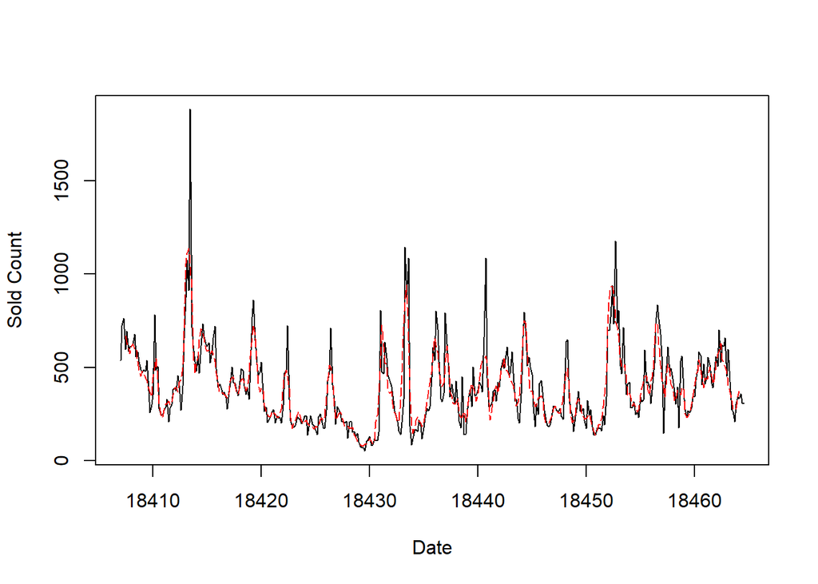

```r
pr6_fitted = pr6_ts_decompose_wm$random - residuals(pr6_auto)
pr6_fitted_transformed = pr6_fitted*pr6_ts_decompose_wm$seasonal*pr6_ts_decompose_wm$trend
plot(pr6_ts_w, xlab="Date", ylab="Sold Count")
points(pr6_fitted_transformed,type="l", col=2, lty=5)
```

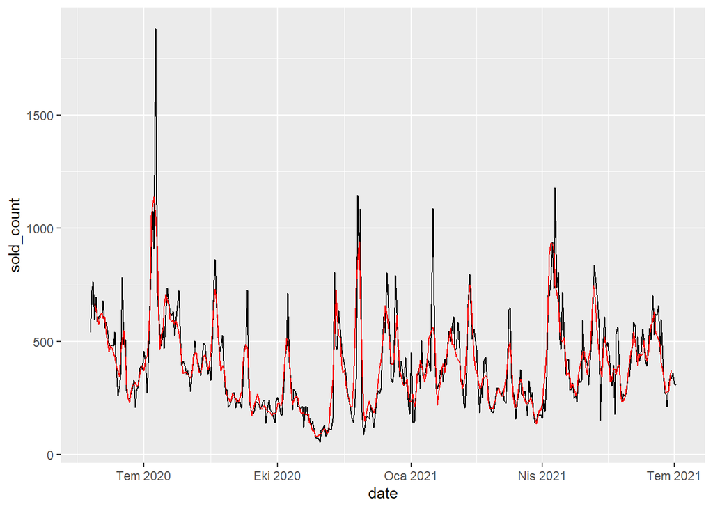

```r
pr6_predictions=cbind(sold_count=pr6_ts_w,fitted=pr6_fitted_transformed)
pr6_predictions=as.data.table(pr6_predictions)
pr6_predictions$date=product6$event_date
ggplot(pr6_predictions, aes(x=date, y=sold_count))+geom_line()+geom_line(aes(y=fitted),col="red")
```

## Product 7

### Data Adjustments

I added new data and sorted observations from old to new.

```r
product7= my_data[my_data$product_content_id==7061886,]
product7=(product7[order(product7$event_date),])
prd7_add=data[data$product_content_id==7061886,]
prd7_add=prd7_add[event_date>="2021-06-01",]
prd7_add
```

```
##      price event_date product_content_id sold_count visit_count favored_count
##  1: 289.00 2021-06-01            7061886         24        1793           203
##  2: 289.00 2021-06-02            7061886         19        1441           108
##  3: 289.00 2021-06-03            7061886         20        1279           130
##  4: 289.00 2021-06-04            7061886         21        1315           149
##  5: 297.75 2021-06-05            7061886         16        1078            78
##  6: 299.00 2021-06-06            7061886         18        1155            78
##  7: 299.00 2021-06-07            7061886         21        1290           104
##  8: 299.00 2021-06-08            7061886         39        1456           106
##  9: 299.00 2021-06-09            7061886         29        1454           141
## 10: 299.00 2021-06-10            7061886         25        1504           107
## 11: 299.00 2021-06-11            7061886         13        1139           110
## 12: 299.00 2021-06-12            7061886         17        1165            98
## 13: 299.00 2021-06-13            7061886         19        1426           109
## 14: 298.64 2021-06-14            7061886         15         964            70
```

[output cut: 87 more lines]

```r
product7=rbind(product7,prd7_add)
```

### Visualizing

The plot of the series is shown below.Mean of the data is not constant. There are several high-sale periods therefore variance is not constant.

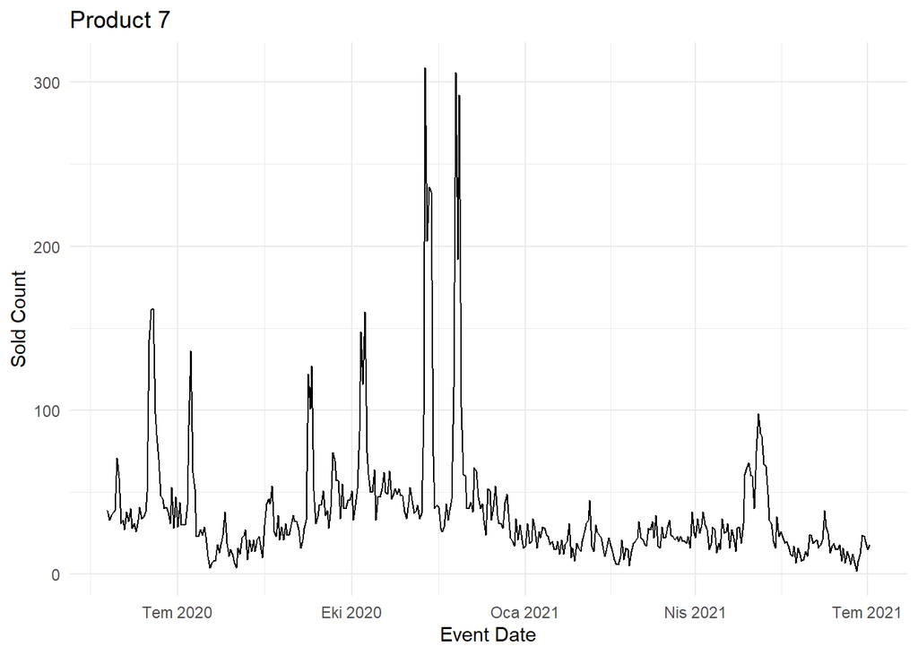

```r
(ggplot(product7,aes(x=event_date,y=sold_count))+
    geom_line()+
    theme_minimal()+
    labs(title="Product 7",y="Sold Count", x="Event Date"))
```

### Analyze Seasonality

In addition to visual analysis, I also used the acf function to test seasonality.

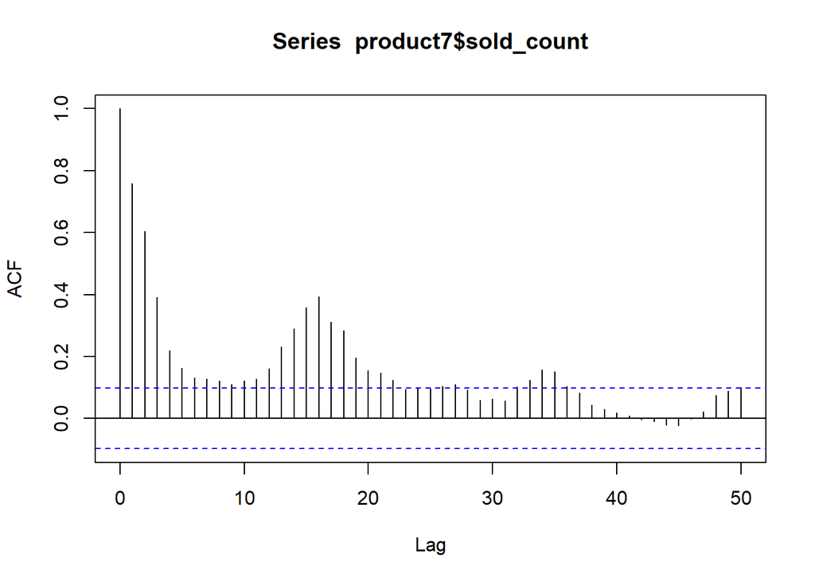

```r
acf(product7$sold_count,50)
```

### Decomposition

I made multiplicative and additive decomposition in weekly and monthly level.

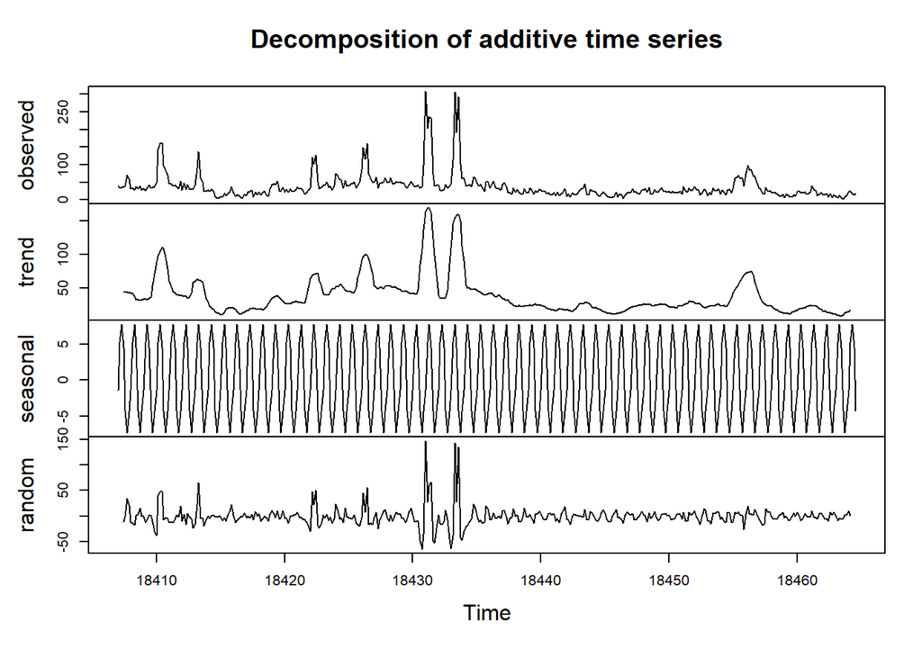

```r
pr7_ts_w=ts(product7$sold_count, frequency=7,start = min(product7$event_date))
pr7_ts_decompose_wa=decompose(pr7_ts_w)
pr7_ts_decompose_wm=decompose(pr7_ts_w, type="multiplicative")
plot(pr7_ts_decompose_wa)
```

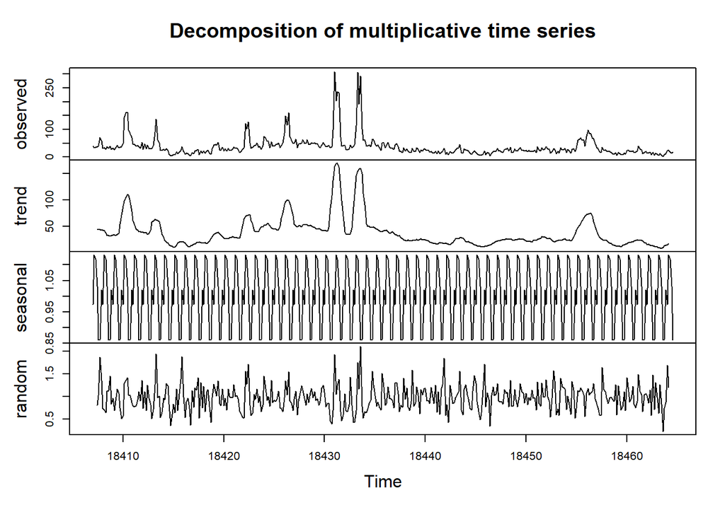

```r
plot(pr7_ts_decompose_wm)
```

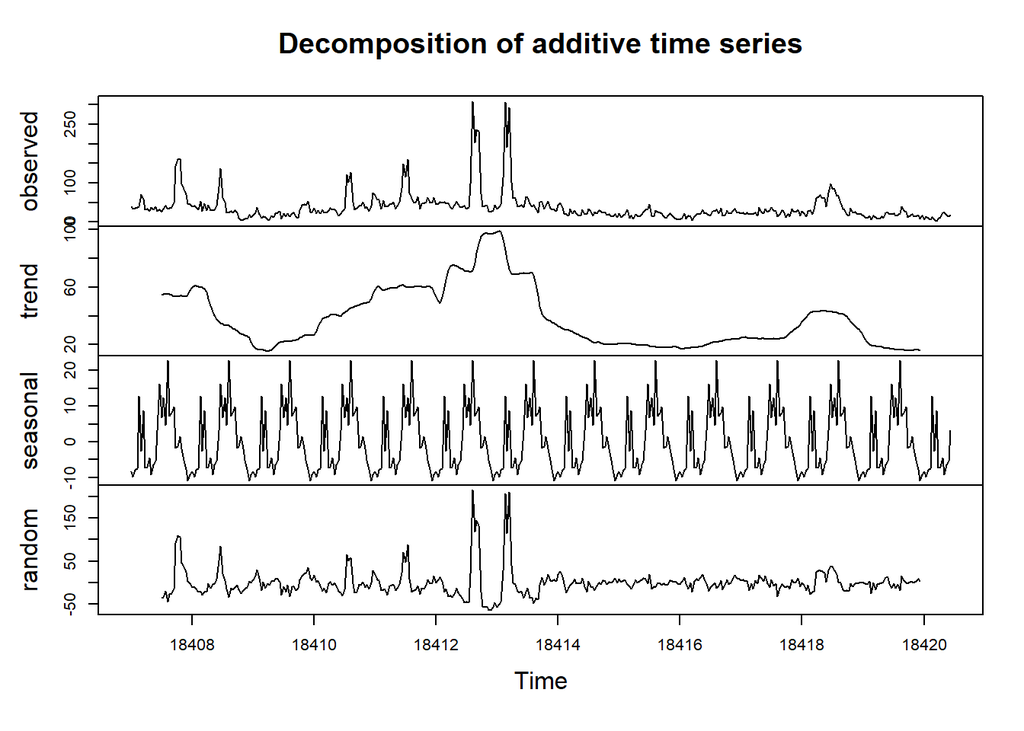

```r
pr7_ts_m=ts(product7$sold_count, frequency=30,start = min(product7$event_date))
pr7_ts_decompose_ma=decompose(pr7_ts_m)
pr7_ts_decompose_mm=decompose(pr7_ts_m, type="multiplicative")
plot(pr7_ts_decompose_ma)
```

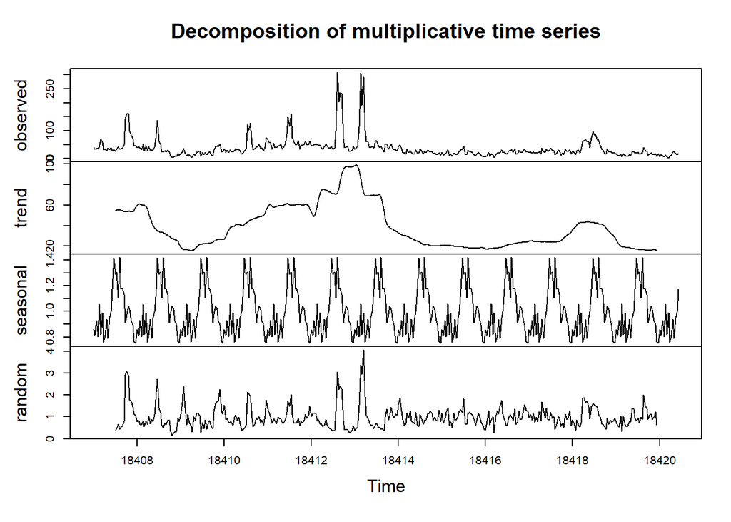

```r
plot(pr7_ts_decompose_mm)
```

### ARIMA

```r
pr7_auto=auto.arima(pr7_ts_decompose_wm$random)
pr7_auto
```

```
## Series: pr7_ts_decompose_wm$random
## ARIMA(5,0,2) with non-zero mean
##
## Coefficients:
##           ar1     ar2      ar3      ar4      ar5     ma1      ma2    mean
##       -0.1907  0.4535  -0.4004  -0.1733  -0.0274  0.1625  -0.6696  0.9806
## s.e.   0.1429  0.1284   0.0549   0.0763   0.0692  0.1348   0.1201  0.0049
##
## sigma^2 estimated as 0.06943:  log likelihood=-30.34
## AIC=78.67   AICc=79.14   BIC=114.55
```

```r
residuals(pr7_auto)
```

[output not shown]

[output cut: 70 more lines]

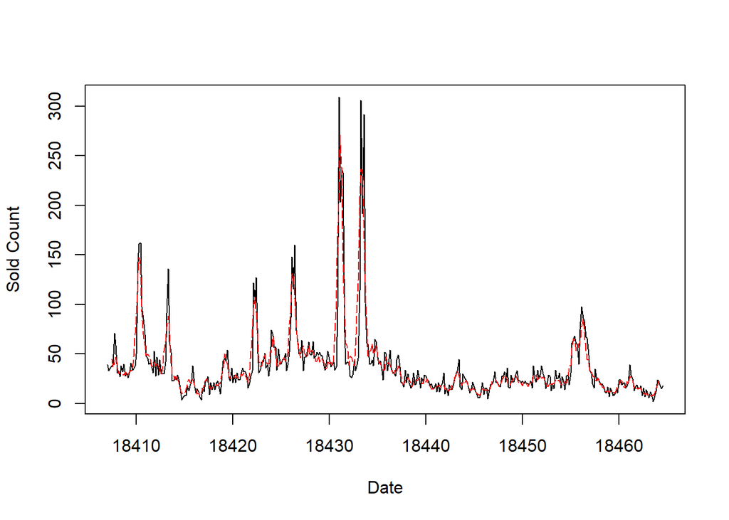

```r
pr7_fitted = pr7_ts_decompose_wm$random - residuals(pr7_auto)
pr7_fitted_transformed = pr7_fitted*pr7_ts_decompose_wm$seasonal*pr7_ts_decompose_wm$trend

plot(pr7_ts_w, xlab="Date", ylab="Sold Count")
points(pr7_fitted_transformed,type="l", col=2, lty=5)
```

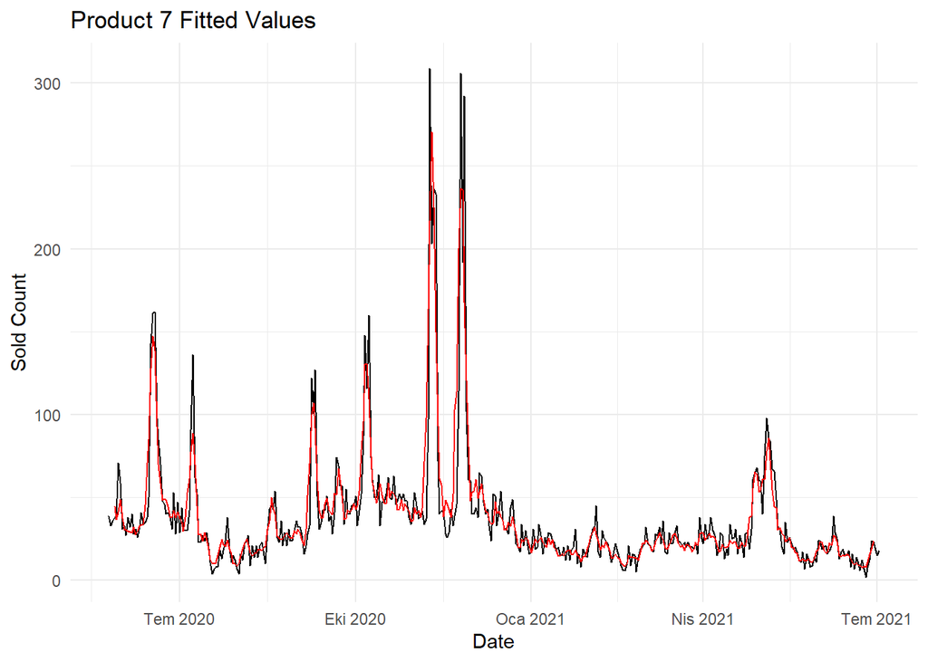

```r
pr7_predictions=cbind(sold_count=pr7_ts_w,fitted=pr7_fitted_transformed)
pr7_predictions=as.data.table(pr7_predictions)
pr7_predictions$date=product7$event_date

ggplot(pr7_predictions, aes(x=date, y=sold_count))+geom_line()+geom_line(aes(y=fitted),col="red")+ theme_minimal()+
  labs(title="Product 7 Fitted Values ", x="Date", y="Sold Count")
```

## Product 8

### Data Adjustments

I added new data and sorted observations from old to new.

```r
product8= my_data[my_data$product_content_id==73318567,]
product8=(product8[order(product8$event_date),])
prd8_add=data[data$product_content_id==73318567,]
prd8_add=prd8_add[event_date>="2021-06-01",]
prd8_add
```

```
##     price event_date product_content_id sold_count visit_count favored_count
##  1: 59.99 2021-06-01           73318567        196       16532          1262
##  2: 60.29 2021-06-02           73318567        134       12866           891
##  3: 59.99 2021-06-03           73318567        106       10033           639
##  4: 59.99 2021-06-04           73318567         63        7477           457
##  5: 59.99 2021-06-05           73318567         58        7339           459
##  6: 59.99 2021-06-06           73318567         23        9567           742
##  7: 59.99 2021-06-07           73318567         53        8335           750
##  8: 59.99 2021-06-08           73318567         59        7556           604
##  9: 61.52 2021-06-09           73318567         36        6507           410
## 10: 60.97 2021-06-10           73318567         56        7314           461
## 11: 62.45 2021-06-11           73318567         44        6745           512
## 12: 59.99 2021-06-12           73318567         39        6749           536
## 13: 61.16 2021-06-13           73318567         44       10354           759
## 14: 59.99 2021-06-14           73318567         67       10221           675
```

[output cut: 87 more lines]

```r
product8=rbind(product8,prd8_add)
```

### Visualizing

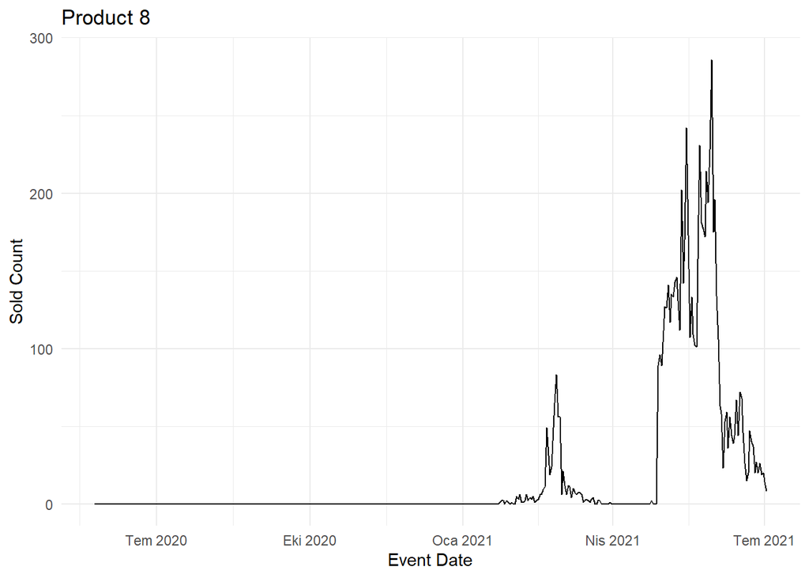

```r
(ggplot(product8,aes(x=event_date,y=sold_count))+
    geom_line()+
    theme_minimal()+
    labs(title="Product 8",y="Sold Count", x="Event Date"))
```

### Analyze Seasonality

In addition to visual analysis, I also used the acf function to test seasonality.

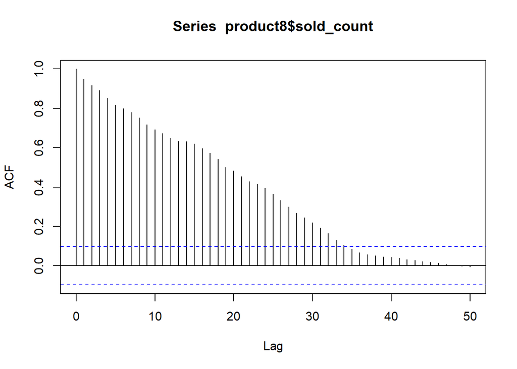

```r
acf(product8$sold_count,50)
```

### Decomposition

I made multiplicative and additive decomposition in weekly and monthly level.

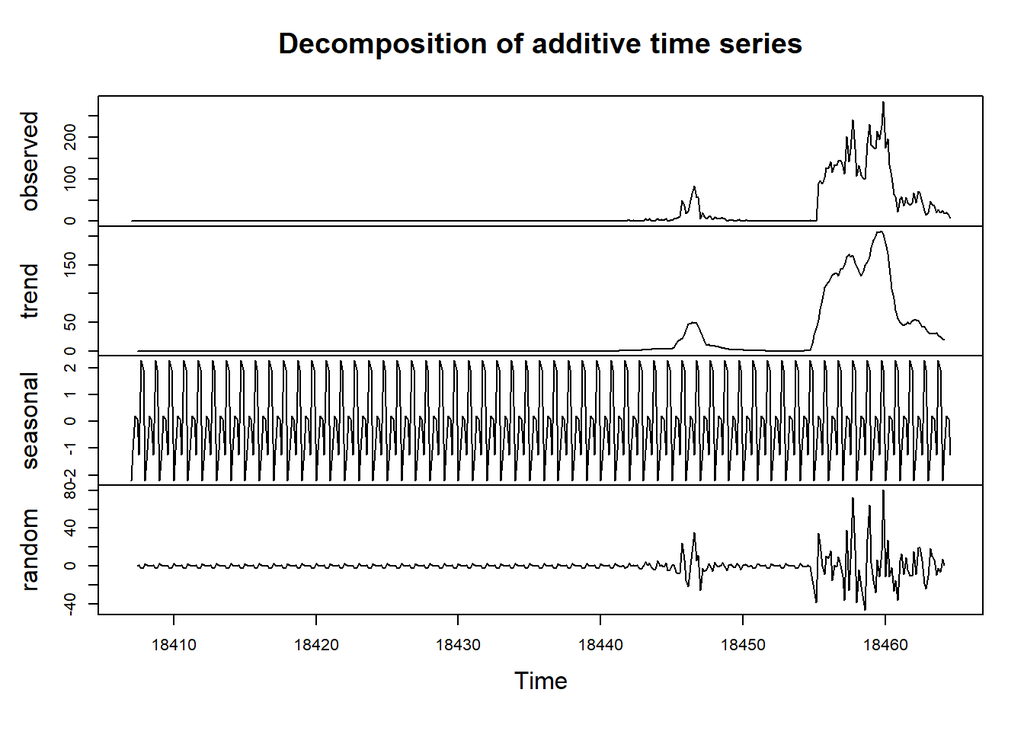

```r
pr8_ts_w=ts(product8$sold_count, frequency=7,start = min(product8$event_date))
pr8_ts_decompose_wa=decompose(pr8_ts_w)
pr8_ts_decompose_wm=decompose(pr8_ts_w, type="multiplicative")
plot(pr8_ts_decompose_wa)
```

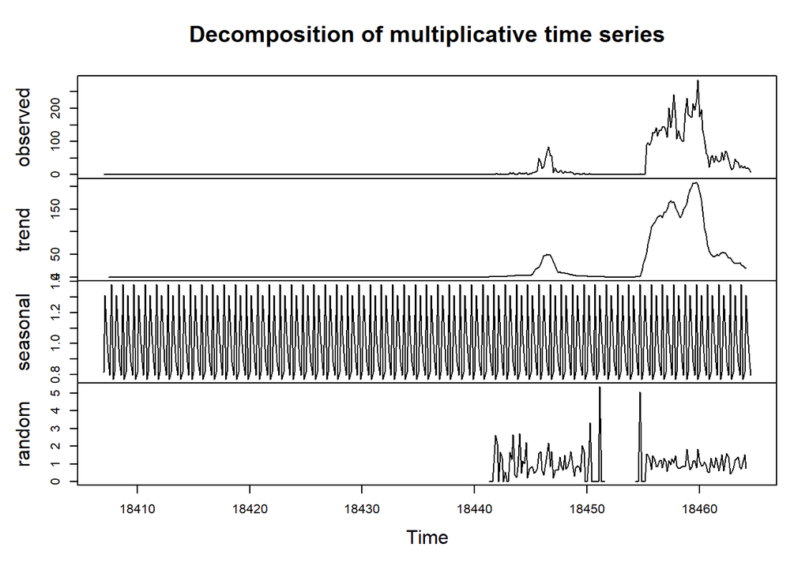

```r
plot(pr8_ts_decompose_wm)
```

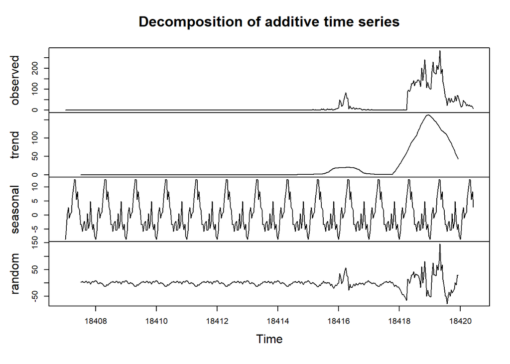

```r
pr8_ts_m=ts(product8$sold_count, frequency=30,start = min(product8$event_date))
pr8_ts_decompose_ma=decompose(pr8_ts_m)
pr8_ts_decompose_mm=decompose(pr8_ts_m, type="multiplicative")
plot(pr8_ts_decompose_ma)
```

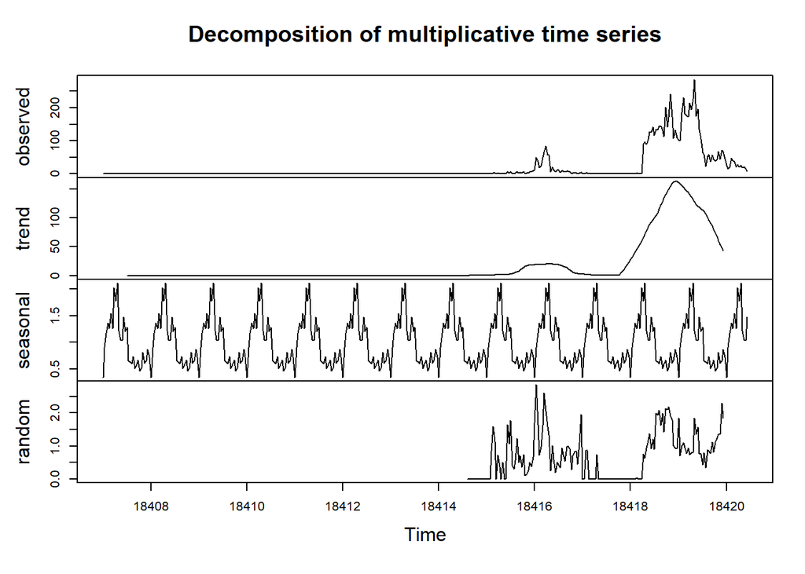

```r
plot(pr8_ts_decompose_mm)
```

### ARIMA

```r
pr8_auto=auto.arima(pr8_ts_decompose_wm$random)
pr8_auto
```

```
## Series: pr8_ts_decompose_wm$random
## ARIMA(0,0,0)(1,0,0)[7] with non-zero mean
##
## Coefficients:
##          sar1    mean
##       -0.0505  0.9825
## s.e.   0.1167  0.0648
##
## sigma^2 estimated as 0.6636:  log likelihood=-172.6
## AIC=351.19   AICc=351.34   BIC=360.44
```

```r
residuals(pr8_auto)
```

[output not shown]

[output cut: 17 more lines]

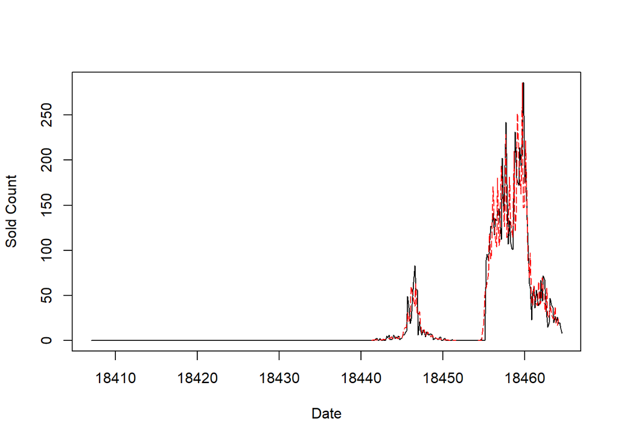

```r
pr8_fitted = pr8_ts_decompose_wm$random - residuals(pr8_auto)
pr8_fitted_transformed = pr8_fitted*pr8_ts_decompose_wm$seasonal*pr8_ts_decompose_wm$trend

plot(pr8_ts_w, xlab="Date", ylab="Sold Count")
points(pr8_fitted_transformed,type="l", col=2, lty=5)
```

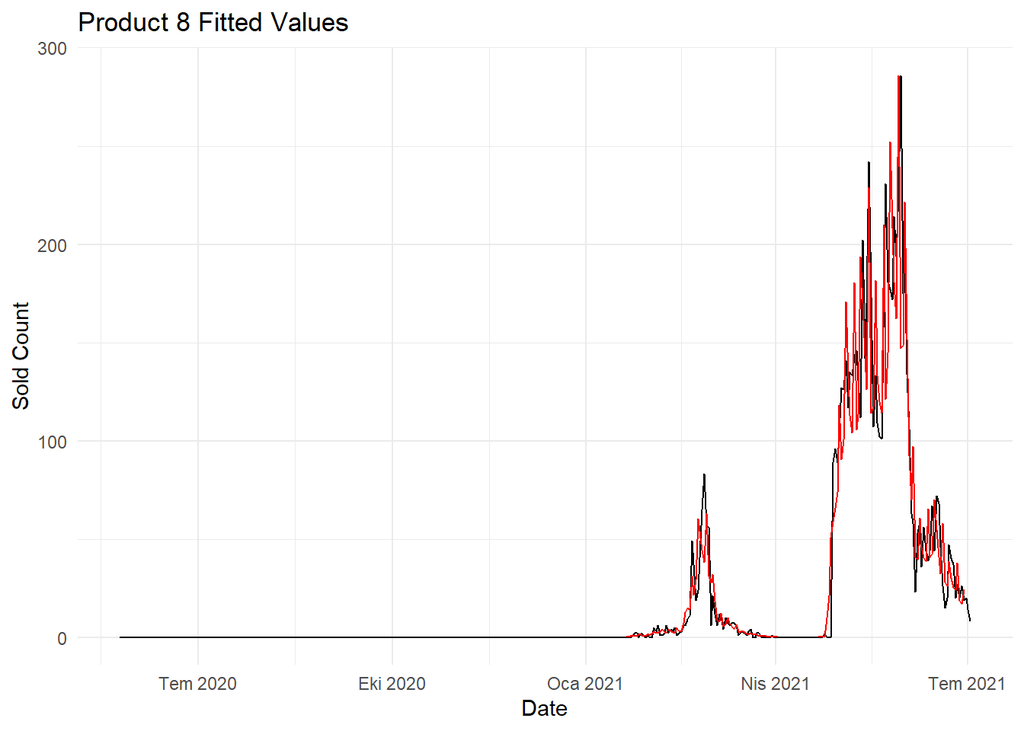

```r
pr8_predictions=cbind(sold_count=pr8_ts_w,fitted=pr8_fitted_transformed)
pr8_predictions=as.data.table(pr8_predictions)
pr8_predictions$date=product8$event_date

ggplot(pr8_predictions, aes(x=date, y=sold_count))+geom_line()+geom_line(aes(y=fitted),col="red")+ theme_minimal()+
  labs(title="Product 8 Fitted Values ", x="Date", y="Sold Count")
```

## Product 9

### Data Adjustments

I added new data and sorted observations from old to new.

```r
product9= my_data[my_data$product_content_id==85004,]
product9=(product9[order(product9$event_date),])
prd9_add=data[data$product_content_id==85004,]
prd9_add=prd9_add[event_date>="2021-06-01",]
prd9_add
```

```
##     price event_date product_content_id sold_count visit_count favored_count
##  1: 85.56 2021-06-01              85004        127        7233          1794
##  2: 85.63 2021-06-02              85004         87        4263           664
##  3: 84.78 2021-06-03              85004         83        4014           716
##  4: 86.80 2021-06-04              85004         82        3502           481
##  5: 85.27 2021-06-05              85004         68        5561          2687
##  6: 84.94 2021-06-06              85004         88        3591           491
##  7: 85.11 2021-06-07              85004         68        2928           431
##  8: 85.01 2021-06-08              85004         64        2691           339
##  9: 92.21 2021-06-09              85004         73        2728           432
## 10: 93.22 2021-06-10              85004        108        4580          1631
## 11: 92.86 2021-06-11              85004         87        4431          1573
## 12: 87.08 2021-06-12              85004         56        3006           452
## 13: 86.40 2021-06-13              85004         95        4081           685
## 14: 89.20 2021-06-14              85004         47        2796           458
```

[output cut: 87 more lines]

```r
product9=rbind(product9,prd9_add)
```

### Visualizing

The plot of the series is shown below.Sales have different means in 2020 and 2021. Variance is not constant in both years.

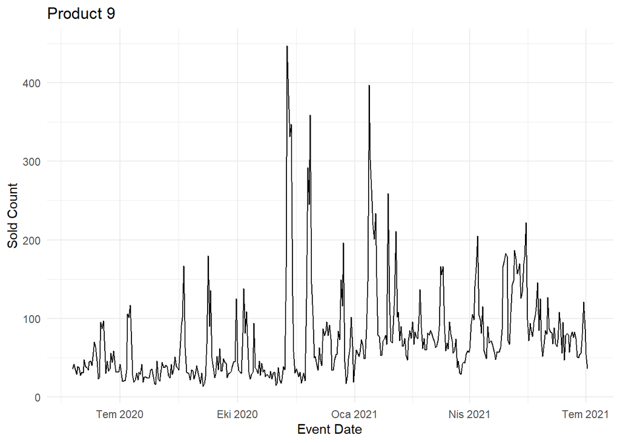

```r
(ggplot(product9,aes(x=event_date,y=sold_count))+
    geom_line()+
    theme_minimal()+
    labs(title="Product 9",y="Sold Count", x="Event Date"))
```

### Analyze Seasonality

In addition to visual analysis, I also used the acf function to test seasonality.

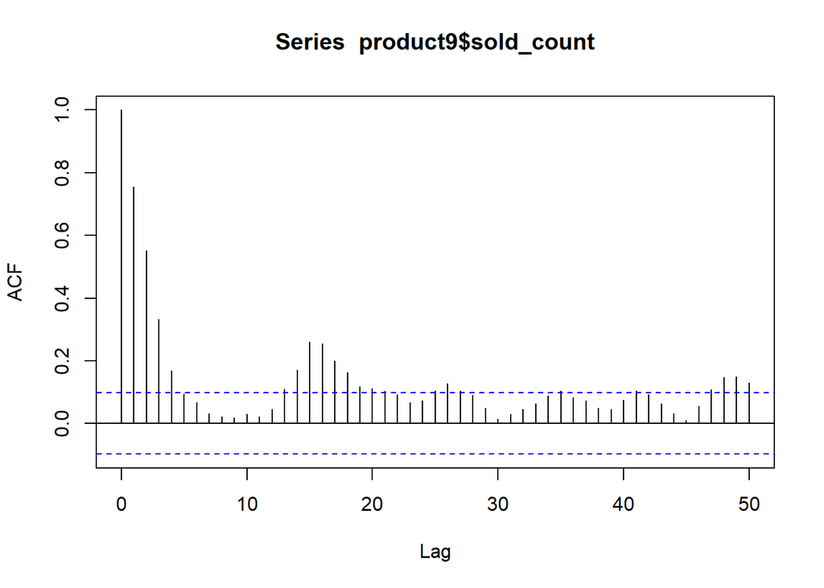

```r
acf(product9$sold_count,50)
```

### Decomposition

I made multiplicative and additive decomposition in weekly and monthly level.

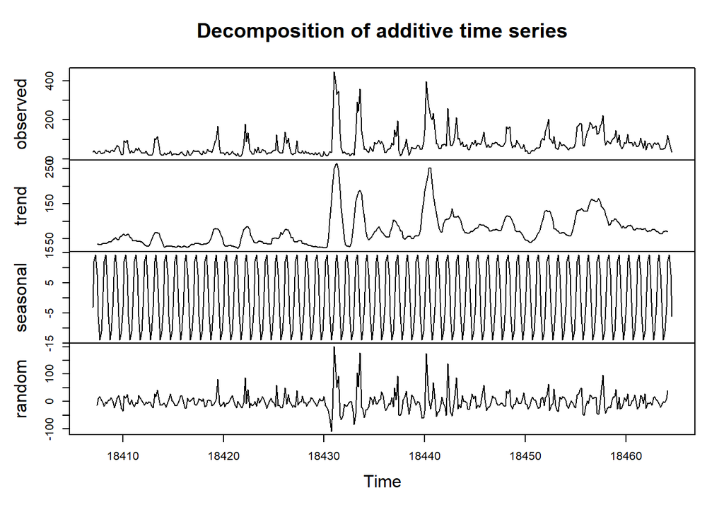

```r
pr9_ts_w=ts(product9$sold_count, frequency=7,start = min(product9$event_date))
pr9_ts_decompose_wa=decompose(pr9_ts_w)
pr9_ts_decompose_wm=decompose(pr9_ts_w, type="multiplicative")
plot(pr9_ts_decompose_wa)
```

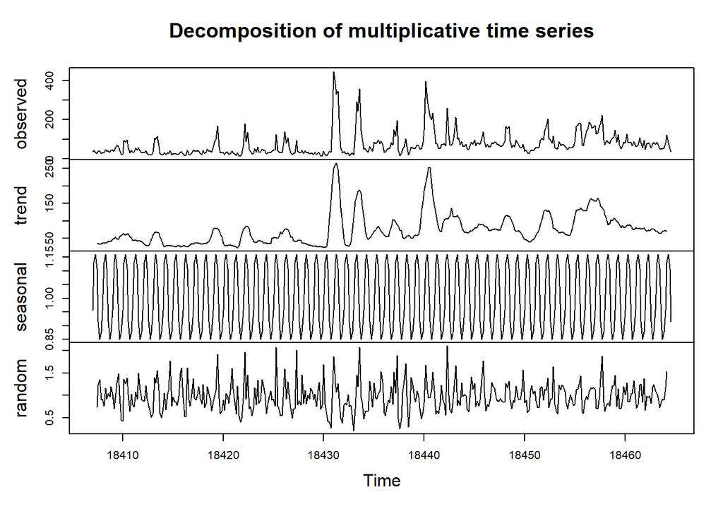

```r
plot(pr9_ts_decompose_wm)
```

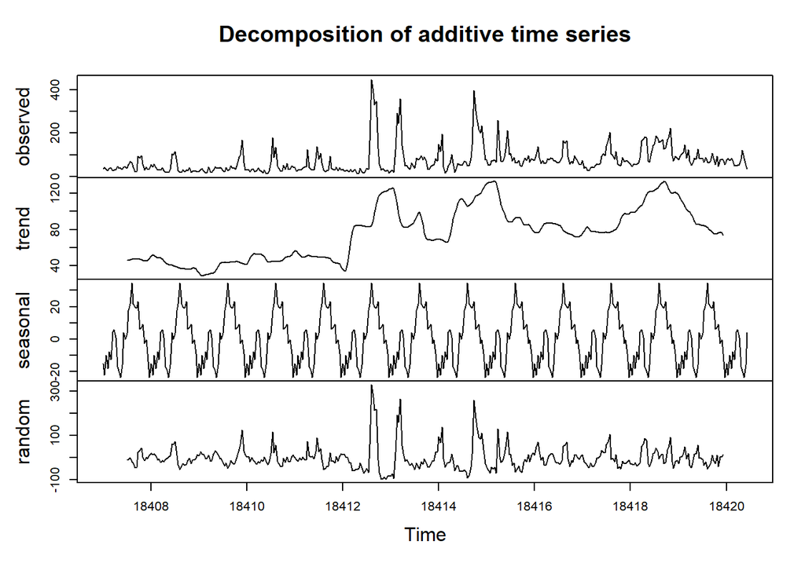

```r
pr9_ts_m=ts(product9$sold_count, frequency=30,start = min(product9$event_date))
pr9_ts_decompose_ma=decompose(pr9_ts_m)
pr9_ts_decompose_mm=decompose(pr9_ts_m, type="multiplicative")
plot(pr9_ts_decompose_ma)
```

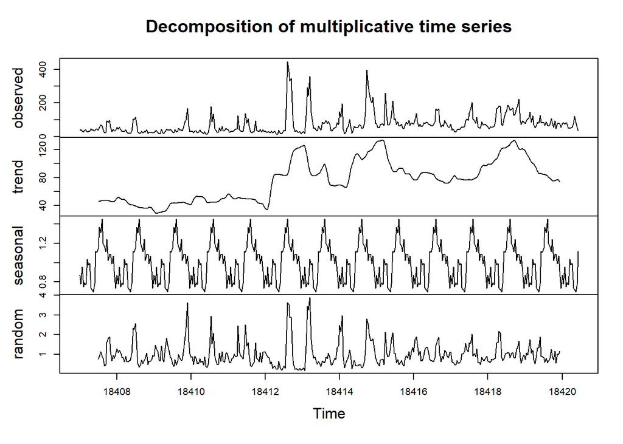

```r
plot(pr9_ts_decompose_mm)
```

### ARIMA

```r
pr9_auto=auto.arima(pr9_ts_decompose_wm$random)
pr9_auto
```

```
## Series: pr9_ts_decompose_wm$random
## ARIMA(5,0,3) with non-zero mean
##
## Coefficients:
##          ar1      ar2      ar3     ar4      ar5      ma1      ma2     ma3
##       1.3428  -0.2112  -0.5832  0.3844  -0.0748  -1.2866  -0.1050  0.4921
## s.e.  0.3397   0.6157   0.3756  0.0856   0.0809   0.3391   0.6102  0.2916
##         mean
##       0.9779
## s.e.  0.0098
##
## sigma^2 estimated as 0.0795:  log likelihood=-57.09
## AIC=134.18   AICc=134.74   BIC=174.04
```

```r
residuals(pr9_auto)
```

[output not shown]

[output cut: 70 more lines]

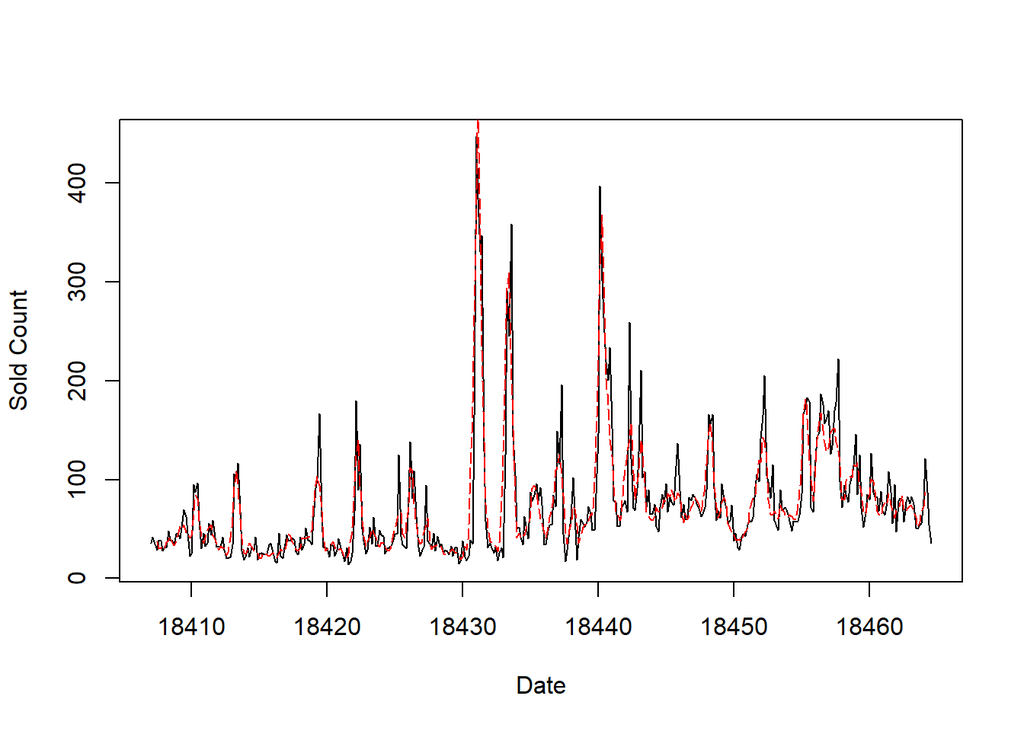

```r
pr9_fitted = pr9_ts_decompose_wm$random - residuals(pr9_auto)
pr9_fitted_transformed = pr9_fitted*pr9_ts_decompose_wm$seasonal*pr9_ts_decompose_wm$trend

plot(pr9_ts_w, xlab="Date", ylab="Sold Count")
points(pr9_fitted_transformed,type="l", col=2, lty=5)
```

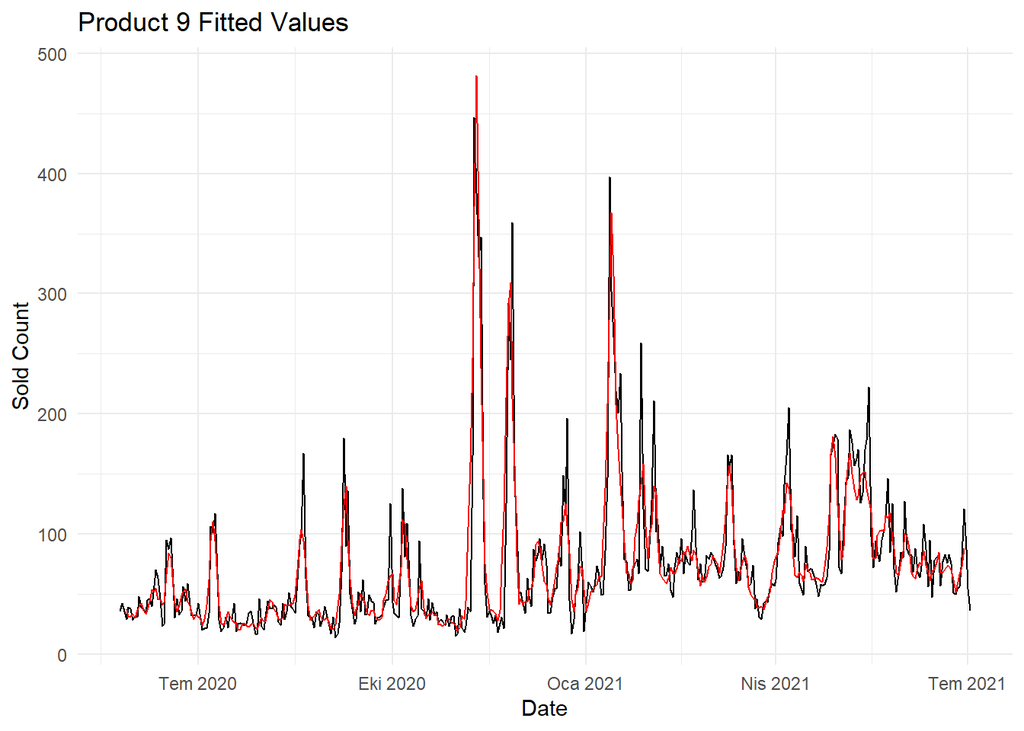

```r
pr9_predictions=cbind(sold_count=pr9_ts_w,fitted=pr9_fitted_transformed)
pr9_predictions=as.data.table(pr9_predictions)
pr9_predictions$date=product9$event_date

ggplot(pr9_predictions, aes(x=date, y=sold_count))+geom_line()+geom_line(aes(y=fitted),col="red")+ theme_minimal()+
  labs(title="Product 9 Fitted Values ", x="Date", y="Sold Count")
```